# 2Gyakorlathoz slides

### Kristályos szerkezet

(Ismétlés)

**Bravais-rács**:

$\mathbf{R}_n=n_1\mathbf{a}_1 + n_2\mathbf{a}_2 + n_3\mathbf{a}_3$, ahol $n_1$, $n_2$, $n_3 \in \mathbb{Z}$

**Bázis**: N db atom

**Elemi cella**

**Bravais cella**

$\mathbf{a_1}$, $\mathbf{a_2}$, $\mathbf{a_3}$ elemi rácsvektorok átírva $\mathbf{\hat{x}}$, $\mathbf{\hat{y}}$, $\mathbf{\hat{z}}$ egységvektorok által kifeszített derékszögű koordináta-rendszerben: $ a_i= a_{ix}\mathbf{\hat{x}} + a_{iy}\mathbf{\hat{y}} + a_{iz}\mathbf{\hat{z}}$

[figure not shown]

$$ a_i= a_{ix}\mathbf{\hat{x}} + a_{iy}\mathbf{\hat{y}} + a_{iz}\mathbf{\hat{z}}$$

$\begin{align} a_i = \begin{pmatrix} a_{ix}\\a_{iy} \\ a_{iz} \end{pmatrix} \end{align}$ $\hspace{10mm}$ $\begin{align} A = \begin{pmatrix} a_{1x} & a_{2x}& a_{3x}\\a_{1y} & a_{2y} & a_{3y} \\ a_{1z} & a_{2z} & a_{3z} \end{pmatrix} \end{align}$ $\hspace{10mm}$

### Az elemi cella térfogata

$V = \mathbf{a_1} \cdot (\mathbf{a_2}\times \mathbf{a_3)}$ $\hspace{10mm}$

$\begin{align} A = \begin{pmatrix} a_{1x} & a_{2x}& a_{3x}\\a_{1y} & a_{2y} & a_{3y} \\ a_{1z} & a_{2z} & a_{3z} \end{pmatrix}\end{align}$

$\mathbf{R}_n=n_1\mathbf{a}_1 + n_2\mathbf{a}_2 + n_3\mathbf{a}_3$ $\hspace{10mm}$ $\mathbf{R}_n=n_1 \begin{pmatrix} a_{1x}\\a_{1y} \\ a_{1z} \end{pmatrix} + n_2\begin{pmatrix} a_{2x}\\a_{2y} \\ a_{2z} \end{pmatrix} + n_3\begin{pmatrix} a_{3x}\\a_{3y} \\ a_{3z} \end{pmatrix} = A\cdot \begin{pmatrix} n_{1}\\n_{2} \\ n_{3} \end{pmatrix}$

## Reciprok rács

$A$ mátrixhoz definiálunk egy $B$ mátrixot úgy, hogy $BA = AB = 2\pi I$. Ekkor $B$ a reciproktérbeli elemi rácsvektorokat tartalmazza.

$\begin{align} B = \begin{pmatrix} b_{1x} & b_{1y}& b_{1z}\\b_{2x} & b_{2y} & b_{2z} \\ b_{3x} & b_{3y} & b_{3z} \end{pmatrix}\end{align}$ $\hspace{10mm}$ $\begin{align} A = \begin{pmatrix} a_{1x} & a_{2x}& a_{3x}\\a_{1y} & a_{2y} & a_{3y} \\ a_{1z} & a_{2z} & a_{3z} \end{pmatrix}\end{align}$

A definícióból következik: $\mathbf{a}_i \mathbf{b}_i = 2\pi\delta_ij$

Egy reciprok rács: $\mathbf{G}=h_1\mathbf{b}_1 + h_2\mathbf{b}_2 + h_3\mathbf{b}_3$, ahol $h_1$, $h_2$, $h_3 \in \mathbb{Z}$

$b_i$ reciproktérbeli rácsvektor két darab elemi rácsvektorra merőleges: $$\mathbf{b}_1=2\pi\frac{\mathbf{a}_2\times\mathbf{a}_3}{\mathbf{a}_1(\mathbf{a}_2\times\mathbf{a}_3)}$$

### Számoljuk ki a grafén reciprokrács vektorait!

$\begin{align} A = \begin{pmatrix} \frac{\sqrt{3}}{2} & -\frac{\sqrt{3}}{2} \\ \frac{3}{2} & \frac{3}{2} \end{pmatrix} a_0\end{align}$

[figure not shown]

### Számoljuk ki a grafén reciprokrács vektorait!

$\begin{align} A = \begin{pmatrix} \frac{\sqrt{3}}{2} & -\frac{\sqrt{3}}{2} \\ \frac{3}{2} & \frac{3}{2} \end{pmatrix}\end{align}$ $\hspace{10mm}$ $\begin{align} B = \begin{pmatrix} \frac{2\pi}{\sqrt{3}} & \frac{2\pi}{3} \\ -\frac{2\pi}{\sqrt{3}} & \frac{2\pi}{3} \end{pmatrix}\end{align}$

[figure not shown]

## A reciproktér **Wigner Seitz** cellája a **Brillouin** cella

[figure not shown]

[figure not shown]

```python
from numpy import array
import scipy.linalg as lin

A = array([[1, 1, 0], [1, 0, 1], [0, 1, 1]])/2
# A-t transzponálni kell, de a kettő megegyezik

B = lin.inv(A)
print(B)
```

```
[[ 1.  1. -1.]
 [ 1. -1.  1.]
 [-1.  1.  1.]]
```

## Kitöltési tényező (Atomic packing factor)

$P=\frac{N_{részecske}V_{részecske}}{V_{cella}}$

[figure not shown]

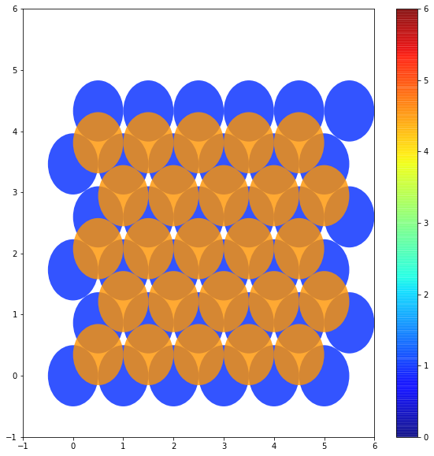

```python
plot_shift(alter=1)
```